# Human Activity Recognition Prediction Assignment

## Project Overview

The goal of this assignment is to predict the manner in which participants did the exercise. This is the “classe” variable in the training set. Any of the other variables can me used to predict with. This report will describe how an accurate model was built, how cross validation was used, what the expected out of sample error is. The final prediction model was used to predict 20 different test cases.

## Training set

Partition testing dataset into 60% testing and 40% testing

The total number of records in the training set is: 11776. The number of records in the cross validation set is 7846.

## Data Cleansing

Remove near zero value columns leaving 54 remaining

## Data Exploration

Plot correlations between ‘classe’ and a selection of other variables.

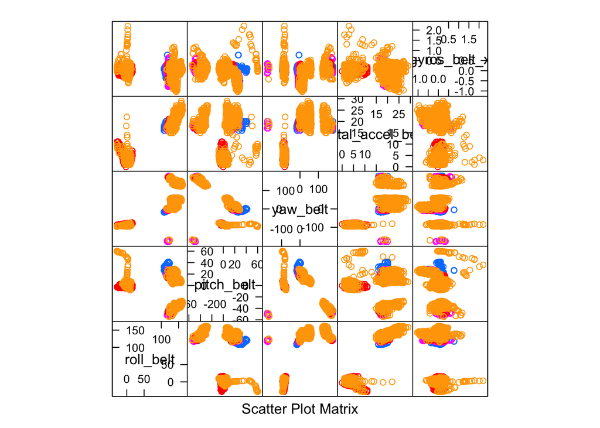

|  | Corr |
| --- | --- |
| roll_belt.total_accel_belt | 0.9805811 |
| roll_belt.accel_belt_y | 0.9234020 |
| total_accel_belt.roll_belt | 0.9805811 |
| total_accel_belt.accel_belt_y | 0.9261817 |
| accel_belt_y.roll_belt | 0.9234020 |
| accel_belt_y.total_accel_belt | 0.9261817 |
| gyros_dumbbell_z.gyros_forearm_z | 0.9585151 |
| gyros_forearm_z.gyros_dumbbell_z | 0.9585151 |

## Model building

```r
# as takes a long time to do all models they were saved as this object
load('/Users/chris/coursera/machine_learning/randomforest2.RData')

#mod1 <- train(classe ~ ., data=training, method="rf")
#mod2 <- train(classe ~ ., data=training, method="gbm")
#mod3 <- train(classe ~ ., data=training, method="lda")
mod1
```

```
## Random Forest
##
## 11776 samples
##    53 predictor
##     5 classes: 'A', 'B', 'C', 'D', 'E'
##
## No pre-processing
## Resampling: Bootstrapped (25 reps)
## Summary of sample sizes: 11776, 11776, 11776, 11776, 11776, 11776, ...
## Resampling results across tuning parameters:
##
##   mtry  Accuracy   Kappa      Accuracy SD  Kappa SD
##    2    0.9902206  0.9876269  0.001892543  0.002393631
##   27    0.9944113  0.9929297  0.001651306  0.002088091
##   53    0.9901349  0.9875192  0.002444772  0.003092326
##
## Accuracy was used to select the optimal model using  the largest value.
## The final value used for the model was mtry = 27.
```

## Cross validation

Run against the cross validation set

```
## Confusion Matrix and Statistics
##
##           Reference
## Prediction    A    B    C    D    E
##          A 2232    3    0    0    0
##          B    0 1514    1    0    0
##          C    0    1 1367    3    0
##          D    0    0    0 1283    2
##          E    0    0    0    0 1440
##
## Overall Statistics
##
##                Accuracy : 0.9987
##                  95% CI : (0.9977, 0.9994)
##     No Information Rate : 0.2845
##     P-Value [Acc > NIR] : < 2.2e-16
##
##                   Kappa : 0.9984
##  Mcnemar's Test P-Value : NA
##
## Statistics by Class:
##
##                      Class: A Class: B Class: C Class: D Class: E
## Sensitivity            1.0000   0.9974   0.9993   0.9977   0.9986
## Specificity            0.9995   0.9998   0.9994   0.9997   1.0000
## Pos Pred Value         0.9987   0.9993   0.9971   0.9984   1.0000
## Neg Pred Value         1.0000   0.9994   0.9998   0.9995   0.9997
## Prevalence             0.2845   0.1935   0.1744   0.1639   0.1838
## Detection Rate         0.2845   0.1930   0.1742   0.1635   0.1835
## Detection Prevalence   0.2849   0.1931   0.1747   0.1638   0.1835
## Balanced Accuracy      0.9997   0.9986   0.9993   0.9987   0.9993
```

The calculated accuracy against the crossvalidation dataset for the random forest model is 0.9987255

Display the top 10 relevant variables

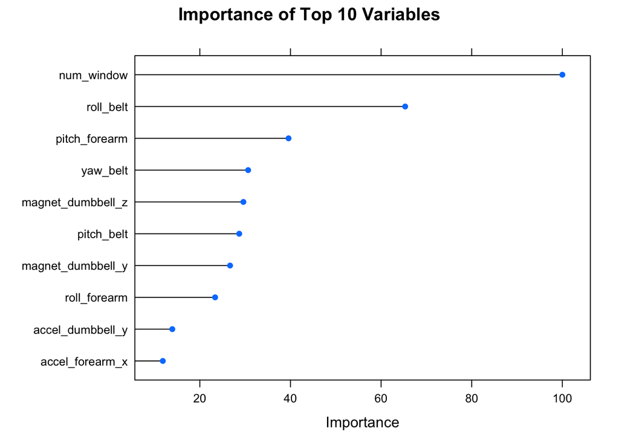

## Testing of the model

```
##  [1] B A B A A E D B A A B C B A E E A B B B
## Levels: A B C D E
```